# Estimating Friction Coefficient for Breaking Cars

Peter Putz

October 12, 2015

## Abstract

In this paper we estimate the friction coefficient for breaking cars. The study is based on empirical data from the R dataset “cars”. The results show that with a confidence level of 95% the friction coefficient lies between 0.193 and 0.241.

## Empirical Data

The R dataset “cars”[^1] provides two data points: the speed of cars in mph and the distances taken to stop in feet. Note that the data were recorded in the 1920s.

```
##   speed dist
## 1     4    2
## 2     4   10
## 3     7    4
## 4     7   22
## 5     8   16
```

In a first step we create a new dataframe `cars_m` with all data converted to metric unit. The speed data are converted to meters per second (m/s) and the distances to meters (m).

```r
cars_m <- data.frame(speed = cars$speed * 0.44704,
                     dist = cars$dist * 0.3048)
head(cars_m, 5)
```

```
##     speed   dist
## 1 1.78816 0.6096
## 2 1.78816 3.0480
## 3 3.12928 1.2192
## 4 3.12928 6.7056
## 5 3.57632 4.8768
```

## Theoretical Breaking Distance and Friction Coefficient

The theoretical breaking distance is determined by the initial speed and the friction coefficient:

$d = \frac{v^2}{2 \mu g}$

d … breaking distance (m)

v … speed (m/s)

$\mu$ … friction coefficient (dimensionless scalar)

g … gravity of the Earth ($\mathrm{m/s^2}$)

Based on the equation above we can derive the friction coefficient as:

$\mu = \frac{v^2}{2dg}$

We will use this equation to calculate friction coefficients based on our empirical data.

## Measured Data

[figure not shown]

```r
fig1 <- plot(dist ~ speed, data=cars,
             xlim = c(0,30),
             ylim = c(0,140),
             main = "Breaking Distance over Speed",
             xlab = "Speed in m/s",
             ylab = "Breaking Distance in m")
```

#### Calculating the Friction Coefficients

Using the equation above we calculate the friction coefficient for each of the 50 observations.

```r
g  <- 9.81
cars_m$friction  <- cars_m$speed^2/(2 * g * cars_m$dist)
head(cars_m, 5)
```

```
##     speed   dist   friction
## 1 1.78816 0.6096 0.26734298
## 2 1.78816 3.0480 0.05346860
## 3 3.12928 1.2192 0.40936894
## 4 3.12928 6.7056 0.07443072
## 5 3.57632 4.8768 0.13367149
```

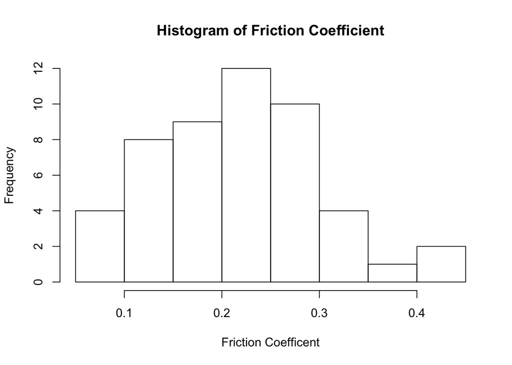

```r
hist(cars_m$friction,
     main = "Histogram of Friction Coefficient",
     xlab = "Friction Coefficent")
```

Next, we calculate the mean friction coefficient and the confidence interval for a confidence level of 95%.

```r
fcMean <- mean(cars_m$friction)
fcCI <- t.test(cars_m$friction, conf.level = 0.95)$conf.int
```

**The mean of our measured friction coefficient is 0.217 with a confidence interval from 0.193 to 0.241 based on a 95% confidence level.**

## Predicted Breaking Distance

We use the measured mean friction coefficient to predict the breaking distance with the following equation:

$d = \frac{v^2}{2 * 0.217 * 9.81}$

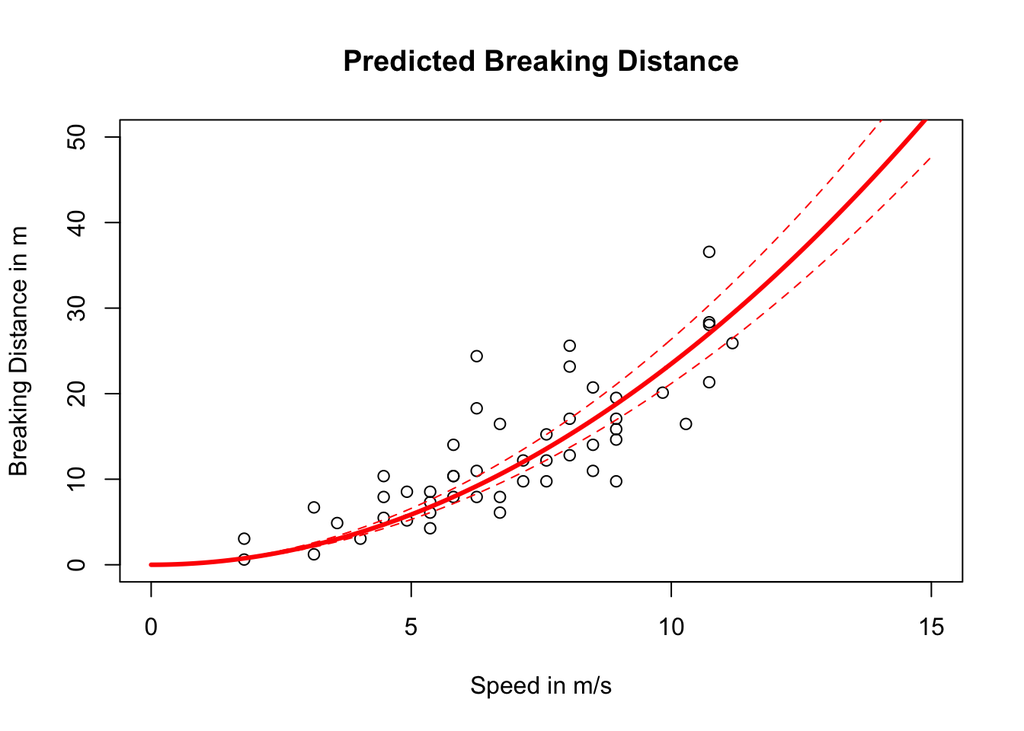

```r
xValues <- seq(0, 15, by = 0.1)
mean <- xValues^2/(2*fcMean*g)
upper <- xValues^2/(2*fcCI[2]*g)
lower <- xValues^2/(2*fcCI[1]*g)

plot(dist ~ speed, data=cars_m,
             xlim = c(0,15),
             ylim = c(0,50),
             main = "Predicted Breaking Distance",
             xlab = "Speed in m/s",
             ylab = "Breaking Distance in m")

lines(xValues, mean, col = "red", lwd = 3)
lines(xValues, upper, col = "red", lty = 2)
lines(xValues, lower, col = "red", lty = 2)
```

## Summary

We calculated the mean friction coefficient based on empirical data from the R dataset “cars” as 0.217 +/- 0.024 (95% confidence interval). We assumed that the friction coefficient is independent from the speed of a vehicle. This assumption needs to be critically investigated in further studies.

[^1]: R Core Team (2015). R: A language and environment for statistical computing. R Foundation for Statistical Computing, Vienna, Austria. URL https://www.R-project.org/.